# Assigment - Naive Bayes fakenews

name author here - Stijn Kuipers(432909)

name reviewer here - No reviewer. Just for practice

11 maart, 2021

```r
library(tidyverse)
library(tm)
library(caret)
library(wordcloud)
library(e1071)
```

Choose a suitable dataset from [this](https://github.com/HAN-M3DM-Data-Mining/assignments/tree/master/datasets) folder and train your own Naive Bayes model. Follow all the steps from the CRISP-DM model.

## Business Understanding

In 2020 spam account for more than 50% of total e-mail traffic (“Spam Statistics: Spam e-Mail Traffic Share 2019” n.d.). This illustrates the value of a good spam filter. Naive Bayes spam filtering is a standard technique for handling spam. It is one of the oldest ways of doing spam filtering, with roots in the 1990s.

## Data Understanding

```r
cleanDF <- read_csv(url)
```

```r
head(rawDF)
```

| id | title | author | text | label |
| --- | --- | --- | --- | --- |
| 0 | House Dem Aide: We Didn’t Even See Comey’s Letter Until Jason Chaffetz Tweeted It | Darrell Lucus | House Dem Aide: We Didn’t Even See Comey’s Letter Until Jason Chaffetz Tweeted It By Darrell Lucus on October 30, 2016 Subscribe Jason Chaffetz on the stump in American Fork, Utah ( image courtesy Mic… | 1 |
| 1 | FLYNN: Hillary Clinton, Big Woman on Campus - Breitbart | Daniel J. Flynn | Ever get the feeling your life circles the roundabout rather than heads in a straight line toward the intended destination? [Hillary Clinton remains the big woman on campus in leafy, liberal Wellesley… | 0 |
| 2 | Why the Truth Might Get You Fired | Consortiumnews.com | Why the Truth Might Get You Fired October 29, 2016 \nThe tension between intelligence analysts and political policymakers has always been between honest assessments and desired results, with the latte… | 1 |
| 3 | 15 Civilians Killed In Single US Airstrike Have Been Identified | Jessica Purkiss | Videos 15 Civilians Killed In Single US Airstrike Have Been Identified The rate at which civilians are being killed by American airstrikes in Afghanistan is now higher than it was in 2014 when the US … | 1 |
| 4 | Iranian woman jailed for fictional unpublished story about woman stoned to death for adultery | Howard Portnoy | Print \nAn Iranian woman has been sentenced to six years in prison after Iran’s Revolutionary Guard searched her home and found a notebook that contained a fictional story she’d written about a woman … | 1 |
| 5 | Jackie Mason: Hollywood Would Love Trump if He Bombed North Korea over Lack of Trans Bathrooms (Exclusive Video) - Breitbart | Daniel Nussbaum | In these trying times, Jackie Mason is the Voice of Reason. [In this week’s exclusive clip for Breitbart News, Jackie discusses the looming threat of North Korea, and explains how President Donald Tru… | 0 |

```r
cleanDF$label <- cleanDF$label %>% factor %>% relevel("1")
class(cleanDF$label)
```

```
[1] "factor"
```

[output not shown]

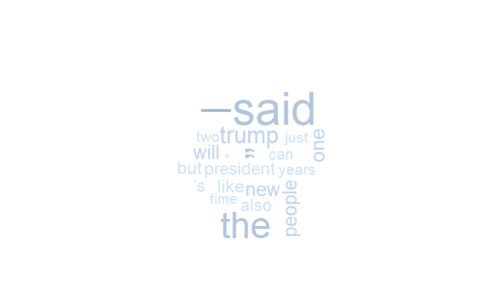

```r
wordcloud(real$text, max.words = 20, scale = c(4, 0.8), colors= c("lightsteelblue1","lightsteelblue2","lightsteelblue3","lightsteelblue"))
```

## Data Preparation

First we need to create a corpus, which refers to a collection of text documents. In our case each message is considered a text document. We’ll use the Corpus() function from thetm package.

```r
cleanCorpus <- Corpus(VectorSource(cleanDF$text))
inspect(cleanCorpus[1:3])
```

```
<<SimpleCorpus>>
Metadata:  corpus specific: 1, document level (indexed): 0
Content:  documents: 3

[1] House Dem Aide: We Didn’t Even See Comey’s Letter Until Jason Chaffetz Tweeted It By Darrell Lucus on October 30, 2016 Subscribe Jason Chaffetz on the stump in American Fork, Utah ( image courtesy Michael Jolley, available under a Creative Commons-BY license) \nWith apologies to Keith Olbermann,…
[2] Ever get the feeling your life circles the roundabout rather than heads in a straight line toward the intended destination? [Hillary Clinton remains the big woman on campus in leafy, liberal Wellesley, Massachusetts. Everywhere else votes her most likely to don her inauguration dress for the rem…
[3] Why the Truth Might Get You Fired October 29, 2016 \nThe tension between intelligence analysts and political policymakers has always been between honest assessments and desired results, with the latter often overwhelming the former, as in the Iraq War, writes Lawrence Davidson. \nBy Lawrence Dav…
```

The corpus contains 20800 documents in 96.7Mb. Which obviously matches with the number of rows in our dataset.

We will use the function tm_map() to do some first cleaning up. First we’ll change everything to lowercase. We’ll also remove numbers as these will contain litle information on a message being spam or not.

For computation efficiency it is important to eliminate all items from a dataset of which you’re rather confident that they’ do’ll add little information to your model. In our case we can expect that words like “and” or “but” will be equally common in both ham and spam messages. We should therefore filter them out before we start modeling. We’ll also remove punctuation.

Now that we have removed certain items, the text lines contain a lot of whitespaces where these items used to be. In our last step we will remove additional whitespace.

```r
cleanCorpus <- cleanCorpus %>% tm_map(tolower) %>% tm_map(removeNumbers)
```

```
transformation drops documentstransformation drops documents
```

```r
cleanCorpus <- cleanCorpus %>% tm_map(tolower) %>% tm_map(removeWords, stopwords()) %>% tm_map(removePunctuation)
```

```
transformation drops documentstransformation drops documentstransformation drops documents
```

```r
cleanCorpus <- cleanCorpus %>% tm_map(stripWhitespace)
```

```
transformation drops documents
```

Let compare the clean version wit the raw version:

```r
tibble(Raw = rawCorpus$content[1:3], Clean = cleanCorpus$content[1:3])
```

| Raw | Clean |
| --- | --- |
| House Dem Aide: We Didn’t Even See Comey’s Letter Until Jason Chaffetz Tweeted It By Darrell Lucus on October 30, 2016 Subscribe Jason Chaffetz on the stump in American Fork, Utah ( image courtesy Mic… | house dem aide didn’t even see comey’s letter jason chaffetz tweeted darrell lucus october subscribe jason chaffetz stump american fork utah image courtesy michael jolley available creative commons li… |
| Ever get the feeling your life circles the roundabout rather than heads in a straight line toward the intended destination? [Hillary Clinton remains the big woman on campus in leafy, liberal Wellesley… | ever get feeling life circles roundabout rather heads straight line toward intended destination hillary clinton remains big woman campus leafy liberal wellesley massachusetts everywhere else votes lik… |
| Why the Truth Might Get You Fired October 29, 2016 \nThe tension between intelligence analysts and political policymakers has always been between honest assessments and desired results, with the latte… | truth might get fired october tension intelligence analysts political policymakers always honest assessments desired results latter often overwhelming former iraq war writes lawrence davidson lawrence… |

Additional adds to the textprocessing function did not work. Now that we have cleaned up the texts, we are going to transform the messages to a matrix. Each word in the each message will get its own column, each row will be a message and the cells of the matrix will contain a word count.

```r
cleanDTM <- cleanCorpus %>% DocumentTermMatrix
inspect(cleanDTM)
```

```
<<DocumentTermMatrix (documents: 20800, terms: 251838)>>
Non-/sparse entries: 5799418/5232430982
Sparsity           : 100%
Maximal term length: 242
Weighting          : term frequency (tf)
Sample             :
       Terms
Docs      —  ’s   “  ” new one people said trump will
  10205 185 202  11 27  27  45     88   65   129   41
  13534   9  82  16  8  15  61    149   16     0  123
  13746 114  31  73 93  27  72     34   24     0   14
  14294   3  30  19  2  15  39     58    4     0   55
  19765   0   0   0  0   0   0      0    0     0    0
  2735    4  62  40 20  17  74     53   17    63  154
  465     2   7 122 31   7  20     14    5     0   16
  5093    3  82  13  3  19  59    105   10     1   61
  7531    1  52  14  4  24  62    126   11     1  143
  8720    5  76  24 10  20  45     83   22     0  143
```

Before we start modeling we need to split all datasets into train and test sets. For this we will use a function from the caret package. The function createDataPartition() can be used to create balanced splits of the data. If the y argument to this function is a factor, the random sampling occurs within each class and should preserve the overall class distribution of the data. In this case we’ll create a 50/50% split.

```r
# Create split indices
set.seed(1234)
trainIndex <- createDataPartition(cleanDF$label, p = .5,
                                  list = FALSE,
                                  times = 1)
head(trainIndex)
```

```
     Resample1
[1,]         2
[2,]         7
[3,]        10
[4,]        11
[5,]        18
[6,]        23
```

```r
# Apply split indices to DF
trainDF <- cleanDF[trainIndex, ]
```

```r
testDF <- cleanDF[-trainIndex, ]

# Apply split indices to Corpus
trainCorpus <- cleanCorpus[trainIndex]
testCorpus <- cleanCorpus[-trainIndex]

# Apply split indices to DTM
trainDTM <- cleanDTM[trainIndex, ]
testDTM <- cleanDTM[-trainIndex, ]
```

As you can check (how?) the DTM has almost *251838* Remember that each feature in the DTM is a word. Some words will have very few counts and therefore will have limited predictive power. To save on computation time we will eliminate words with low frequencies.

```r
freqWords <- trainDTM %>% findFreqTerms(20)
trainDTM <-  DocumentTermMatrix(trainCorpus, list(dictionary = freqWords))
testDTM <-  DocumentTermMatrix(testCorpus, list(dictionary = freqWords))
```

Another issue is that the Naive Bayes classifier is typically trained on categorical features. We now have numerical matrix with word counts. We will transform the counts into a factor that simply indicates whether the word appears in the document or not. We’ll first build our own function for this and then apply it to each column in the DTM.

```r
convert_counts <- function(x) {
  x <- ifelse(x > 0, 1, 0) %>% factor(levels = c(0,1), labels = c("Real", "Fake"))
}
```

```r
nColsDTM <- dim(trainDTM)[2]
```

```r
trainDTM <- apply(trainDTM, MARGIN = 2, convert_counts)
```

```r
testDTM <- apply(testDTM, MARGIN = 2, convert_counts)
```

```r
head(trainDTM[,1:10])
```

[output not shown]

## Modeling

We have now everything in place to start training our model and evaluate against our test dataset. The naiveBayes() function is part of the e1071 package. It takes in the features and labels of our training dataset and returns a trained model.

```r
nbayesModel <-  naiveBayes(trainDTM, trainDF$label, laplace = 1)
```

The model van be applied to the test features using the predict() funtion which generates a vector of predictions. Using a confusion matrix we can analyze the performance of our model.

```r
predVec <- predict(nbayesModel, testDTM)
```

```r
confusionMatrix(predVec, testDF$label, positive = "Fake", dnn = c("Prediction", "True"))
```

[output not shown]

## Evaluation and Deployment

###Questions:

#### What do you think is the role of the laplace parameter in the naiveBayes() function?

Laplace smoothing is a smoothing technique that helps tackle the problem of zero probability in the Naïve Bayes machine learning algorithm. So when a word does not exist in one of the data sets it doesn’t return as zero in the calculation. by adding 1 it will only give a small probability to whether that word is found in spam or normal message.

#### What would you consider as more costly: high false negatives or high false positives levels? Why?

Since the model predicts spam =/= True positive. And I can imagine you don’t want your real sms in your spam. So False Negatives are more costly. True negative are your real sms.